# Презентация лабораторной работы №5

Операционные системы

Соколова А.О. НКАбд-05-23

Российский университет дружбы народов, Москва, Россия

09 марта 2024

## Цель работы

Приобрести навыки работы с менеджерами паролей и файлами конфигураций и настроить рабочую среду

## Задание

Провести установку и настройку менеджера паролей Pass Научиться использовать chezmoi для управления файлами конфигурации домашнего каталога пользователя

# Выполнение лабораторной работы

## Выполнение лабораторной работы

Провожу установку менеджера паролей (рис 3.1)

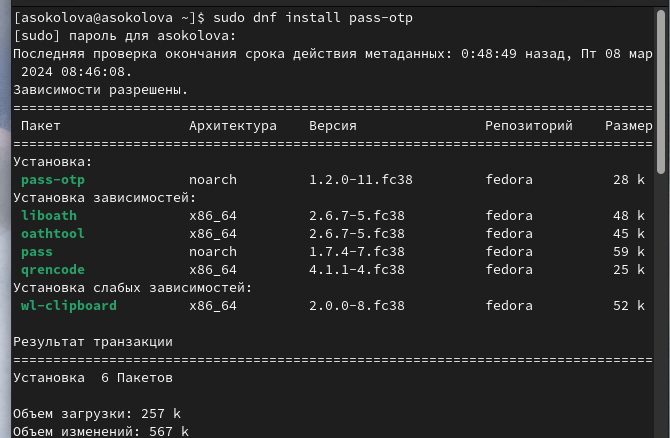

Установка менеджера паролей

## Выполнение лабораторной работы

Продолжаю установку (рис 3.2)

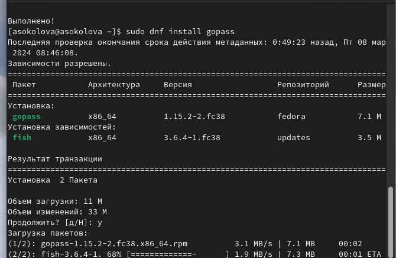

Установка менеджера паролей

## Выполнение лабораторной работы

Просматриваю список ключей GPG (рис 3.3)

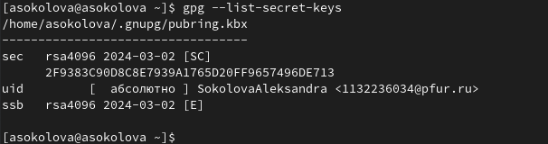

Просмотр списка ключей

## Выполнение лабораторной работы

Инициализирую хранилище (рис 3.4)

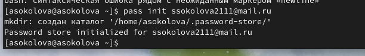

Инициализация хранилища

## Выполнение лабораторной работы

Создаю структуру git для ее синхронизации(рис 3.5)

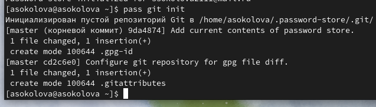

Создание структуры git

## Выполнение лабораторной работы

Задаю адрес нового репозитория на хостинге (рис 3.6)

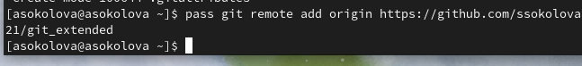

Прикрепление репозитория

## Выполнение лабораторной работы

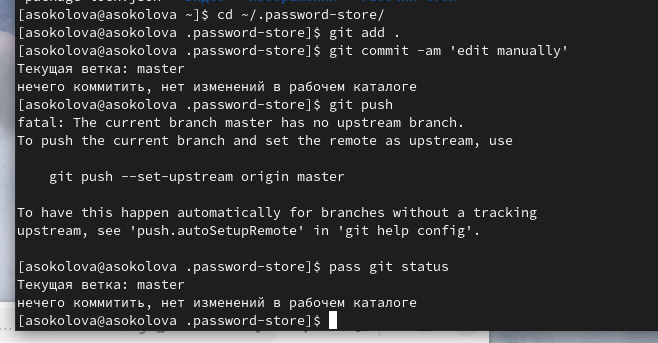

## Выполнение лабораторной работы

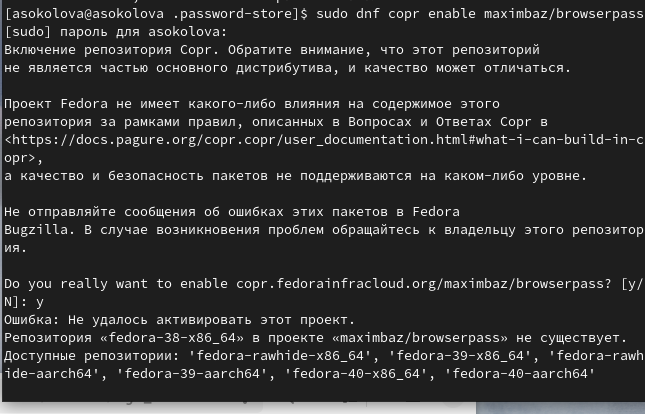

## Выполнение лабораторной работы

Провожу установку необходимого ПО для управления файлами конфигурации (рис 3.9)

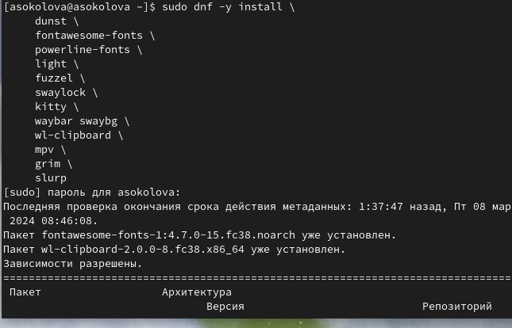

Установка ПО

## Выполнение лабораторной работы

Устанавливаю необходимые шрифты (рис 3.10)

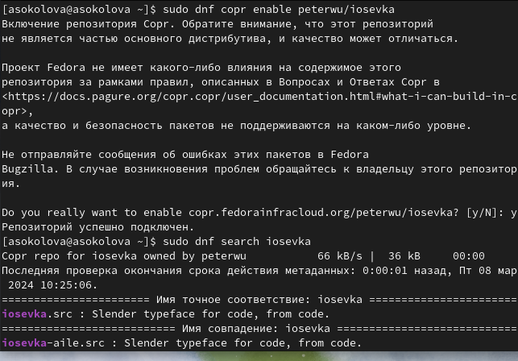

Установка шрифтов

## Выполнение лабораторной работы

Продолжаю установку шрифтов (рис 3.11)

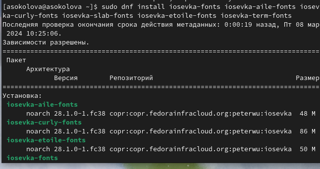

Установка шрифтов

## Выполнение лабораторной работы

Устанавливаю бинарный файл (рис 3.12)

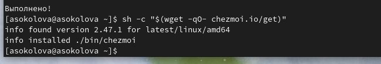

Установка бинарного файла

## Выполнение лабораторной работы

Создаю репозиторий на основе необходимого шаблона (рис 3.13)

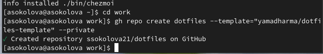

Создание рпеозитория

## Выполнение лабораторной работы

Инициализирую chezmoi с моим репозиторием dotfiles (рис 3.14)

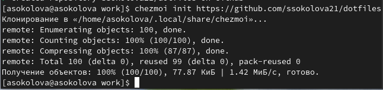

Инициализирую chezmoi

## Выполнение лабораторной работы

Проверяю внесенные изменения и применяю их (рис 3.15)

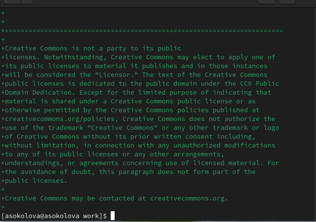

Проверка изменений

## Выполнение лабораторной работы

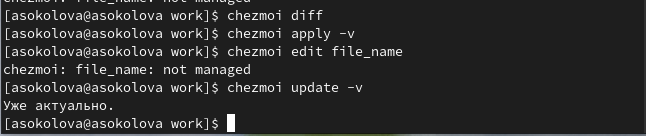

Повторный запуск chezmoi

## Выполнение лабораторной работы

Устанавливаю свои dotfiles на новый компьютер (рис 3.17)

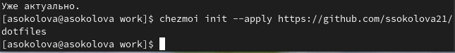

Установка своих dotfiles

## Выполнение лабораторной работы

Извлекаю изменения из репозитория и применяю их (рис 3.18)

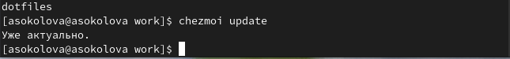

chezmoi update

## Выполнение лабораторной работы

Извлекаю последние изменения из репозитория, проверяю и применяю их (рис 3.19)

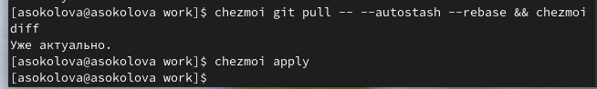

Извлечение и применение изменений

## Выполнение лабораторной работы

Настраиваю автоматическое фиксирование и отправление изменений (рис 3.20)

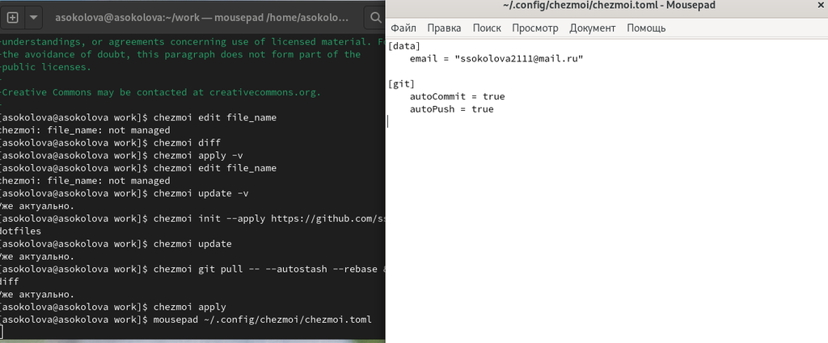

Автоматическое обновление репозитория

## Выводы

В ходе работы я приобрела навыки работы с менеджерами паролей и файлами конфигураций и настроила рабочую среду